# Sites overview Franconia

Maria Potterf

7/15/2022

#### MS: Early indication of post-disturbance reorganization in Central European forests

The number of samples triplets by dominant tree species. Each triplet has 3 management categories:

- Cleared
- Dead
- Living

## Sites overview:

### Triplets counts: 40

Currently we have 40 triplets. Stratification by dominant tree species:

[output not shown]

#### Number of plots (4m2) per triplet&category : 1244

In total, we have 1244 sites (~ 10 plots per triplet& category).

#### Propensity for forest reorganization:

Changes in forest structure and composition:

Outcomes: !!! complete!

- restructuring - changes in structure
- reassembly - changes in composition
- replacement -
- resilience - no changes
- forest structure:
  - density of regeneration (here less< 2m height)
  - height diversity*to be completed (not in report)
- forest composition:
  - Shannon index
  - effective number of species
- ecological traits (based on Niinements (2006)), community weighted means (CWM)
  - CWM shading tolerance
  - CWM drought tolerance

### Regeneration density

Regeneration density of the forest regeneration (<2m). Each subsite have been corrected for the differences in slope. The sum values of regenerated tree species counts were divided by the number of subsites.

| dom_sp | cleared | dead | living |
| --- | --- | --- | --- |
| beech | 3385.1±4721.5 | 5948.9±6018.5 | 5784.6±8284.3 |
| oak | 4820±8536.4 | 12081±24373 | 5974.2±13570.5 |
| pine | 5417.9±3871.8 | 8768.8±14935 | 6207.4±11341.5 |
| spruce | 2180.9±4514.9 | 5254.1±12660.9 | 2285.1±3478 |

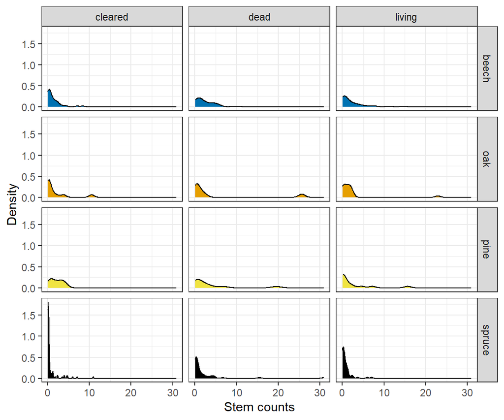

Regeneration density (number of stems per site for trees > 20 cm and <2m tall). All tre species are grouped. Plots represent means +- standard error.

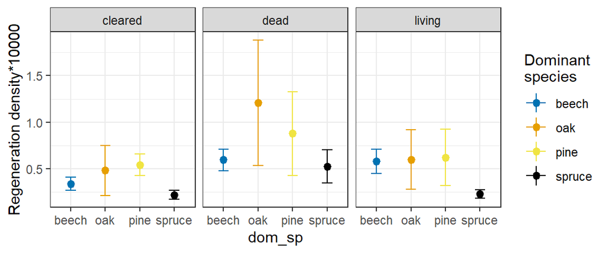

#### Shannon index:

Plots represent means +- standard error.

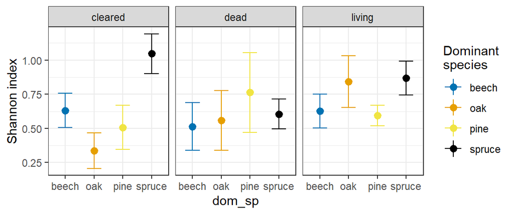

#### Shannon index: effective number of species

Plots represent means +- standard error.

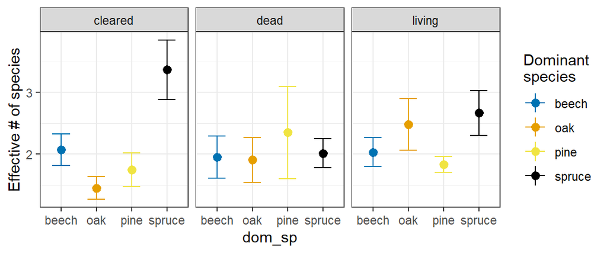

### Community traits

**shade tolerance**:

- higher number = more tolerance (fir),
- lower number = less tolerence (more sunny site, pine)

**drought tolerance**:

- higher = more tolerance (pine),
- lower = less (more drought sensitive, spruce)

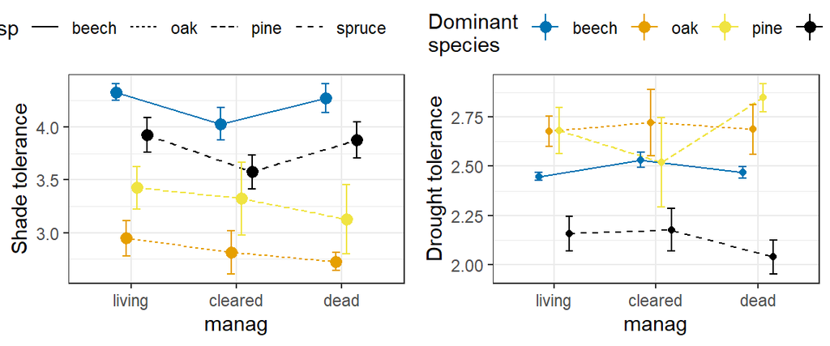

#### Reorganization:

- in structure* to be completed
- in composition

Outcomes for the paper:

- no change -> resilience
- in structure -> restructure
- in composition -> reassemble
- in structure&composition -> replace/shift

Outcomes here just indicates if the regeneration species correspond to dominant species in the matre tree composition.

If the density of the regeneration tree species:

- more than 50% of stems: **resilience**
- if 25-50%: **decrease**
- if 0-25%: **species change** -> changes in compositions

How do the sites change their composition?

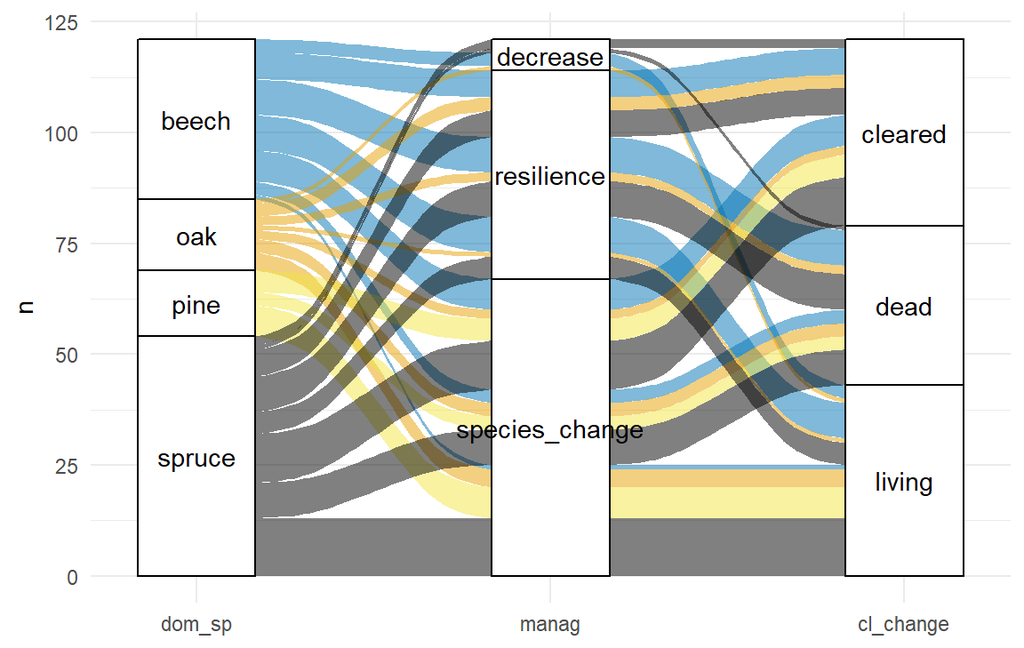

What are the species prevailing in regeneration?

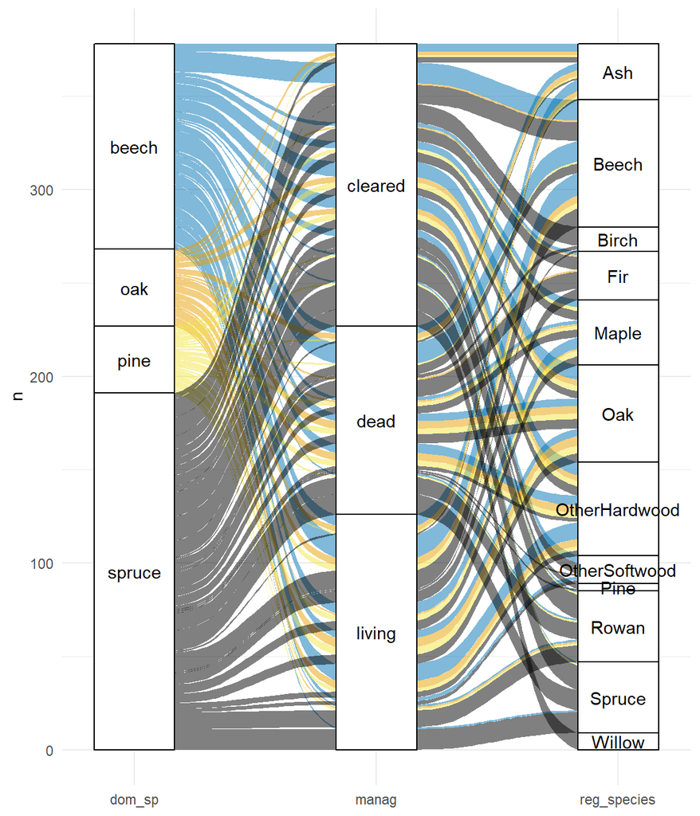